# KD Practicum 2.3

## Recursive vectors

In R, **recursive vectors** act as containers. Unlike atomic vectors, its contents are not restricted to a single mode and can encompass any data type. Recursive vectors are also called **lists**, because a list can contain other lists.

We can create lists using the `list()` function, or coerce other objects with `as.list()`. Note that each element of this list is named. Names of list elements can be provided as formal parameters to the `list()` constructor using the `=` operator.

```r
list(first = list(alpha = 1:5,
                  beta = 6:10),
     second = "Hello World!",
     third = TRUE)
```

```
## $first
## $first$alpha
## [1] 1 2 3 4 5
##
## $first$beta
## [1]  6  7  8  9 10
##
##
## $second
## [1] "Hello World!"
##
## $third
## [1] TRUE
```

The resulting list comes out as a composition of:

- another list with two elements (each of which is a vector itself),
- a character vector,
- and a single-unit Boolean vector.

Each element of a list starts with name, which can be accessed using the `$` sign operator.

The property that makes recursive vectors fundamentally different from atomic vectors is that instead of storing the values itself, they store references to them: `l1 <- list(1,2,3)`

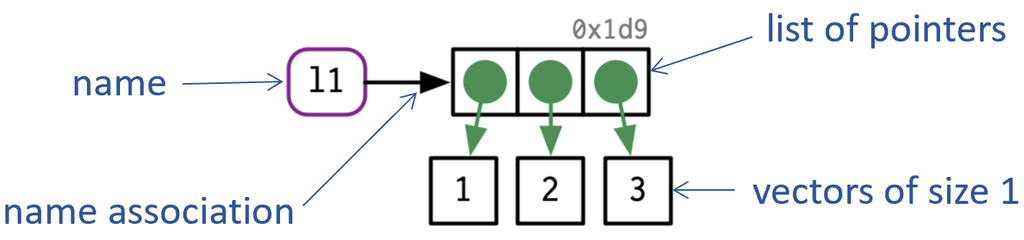

Like vectors, lists use copy-on-modify behavior; the original list is left unchanged, and R creates a modified copy. This, however, is a **shallow copy**: the list object and its bindings are copied, but the values pointed to by the bindings are not. The opposite of a shallow copy is a **deep copy** where the contents of every reference are copied. Prior to R 3.1.0, copies were always deep copies.

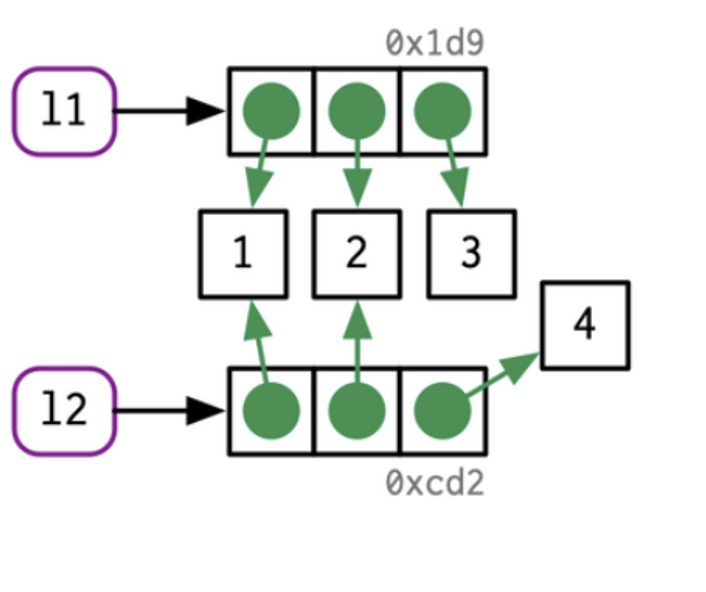

**Question 1:** What do you think happens and how is this different to copy-on-modify behavior of the atomic vectors? Use `tracemem()` to find out.

### Data frames 1.0

The two most important applications of lists are **data frames** and **tibbles**. A data frame is a column-bind list of vectors with attributes for (column) names, **row.names**, and its class, “data.frame”. In contrast to a regular **list**, a data frame has an additional constraint: the length of each of its vectors must be the same. This gives data frames their rectangular structure and explains why they share the properties of both matrices and lists.

- A data frame has `rownames()`, `colnames()`. When `names()` are used on a data frame then the column names are returned.
- A data frame has `nrow()` rows and `ncol()` columns. `dim()` returns a vector containing the number of rows and columns.

Note that data frames are column-bound vectors, so copy-on-modify has important consequences when you modify a data frame. Take this data frame as an example: `d1 <- data.frame(x = c(1,5,6), y = c(2,4,3))`.

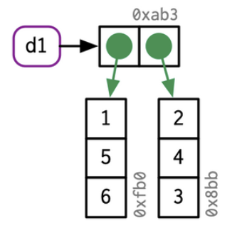

If you modify a column, the others will still point to their original references. However, if you modify a row, every column will be modified. This will have severe memory implications if a data frame is large.

```r
d1 <- data.frame(x = c(1,5,6), y = c(2,4,3))
d2 <- d1
# Multiply each value of the second column by 2.
d2[, 2] <- d2[, 2] * 2
d3 <- d1
# Multiply each value of the first row by 3.
d3[1, ] <- d3[1, ] * 3
```

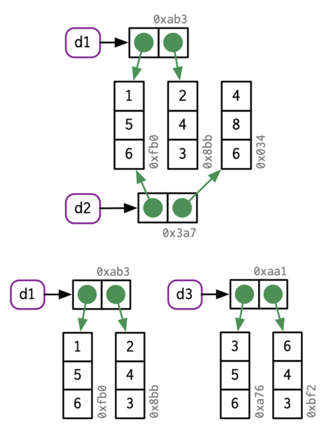

### Data frames 2.0: tibbles and tribbles

Data frames are one of the biggest and most important ideas in R, and one of the things that make R different from other programming languages. However, in the over 20 years since their creation, the ways that people use R have changed, and some of the design decisions that made sense at the time data frames were created now cause frustration.

This frustration lead to the creation of the **tibbles and tribbles**, a modern re-imagining of the data frame. They are designed to be (as much as possible) drop-in replacements for data frames that fix those frustrations.

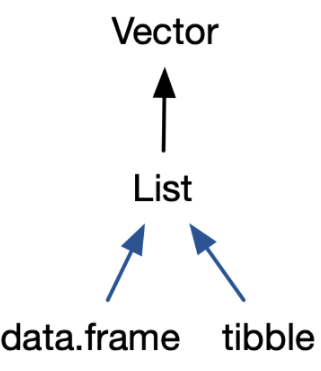

Almost all of the functions that we will use require tibbles, as tibbles are one of the unifying features of the tidyverse. Most other R packages use regular data frames, so we might want to coerce a data frame to a tibble. We can do that with `as_tibble()`:

```r
library(tidyverse)
head(as_tibble(mtcars), 5)
```

```
## # A tibble: 5 × 11
##     mpg   cyl  disp    hp  drat    wt  qsec    vs    am  gear  carb
##   <dbl> <dbl> <dbl> <dbl> <dbl> <dbl> <dbl> <dbl> <dbl> <dbl> <dbl>
## 1  21       6   160   110  3.9   2.62  16.5     0     1     4     4
## 2  21       6   160   110  3.9   2.88  17.0     0     1     4     4
## 3  22.8     4   108    93  3.85  2.32  18.6     1     1     4     1
## 4  21.4     6   258   110  3.08  3.22  19.4     1     0     3     1
## 5  18.7     8   360   175  3.15  3.44  17.0     0     0     3     2
```

You can create a new tibble from individual vectors with `tibble()`. Note that unlike data frames, only single values are recycled.

```r
x <-1:5 ; tibble(x, rnorm(5), TRUE)
```

```
## # A tibble: 5 × 3
##       x `rnorm(5)` `TRUE`
##   <int>      <dbl> <lgl>
## 1     1     -1.57  TRUE
## 2     2      0.497 TRUE
## 3     3      0.204 TRUE
## 4     4      0.312 TRUE
## 5     5      1.43  TRUE
```

### Advanced subsetting operators

You have learned basic subsetting operations using the square bracket operator `[]`. However, there are two other subsetting operators: `[[` and `$`. `[[` is used for extracting single items, while `x$y` is a useful shorthand for `x[["y"]]`.

### The [[ operator

`[[` is most important when working with lists because subsetting a list with `[` always returns a smaller list.

Since most ML modelling functions require one or more vector(s) for input, you need to use `[[` to extract those from a list, or a data frame. Simple `[` won’t do the job. The same principle applies on mining ML model objects, which we will learn at week 4.

To help make this easier to understand we can use a metaphor:

> If list `x` is a train carrying objects, then `x[[5]]` is the object in car 5; `x[4:6]` is a train of cars 4-6.

Let’s use this metaphor to make a simple list:

```r
x <- list(1:3, "a", 4:6)
```

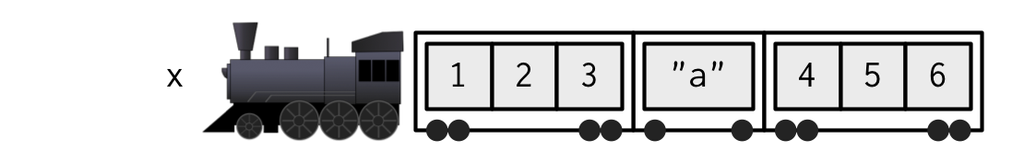

When extracting a single element, you have two options: you can create a smaller train, i.e., fewer carriages, or you can extract the contents of a particular carriage. This is the difference between `[` and `[[`:

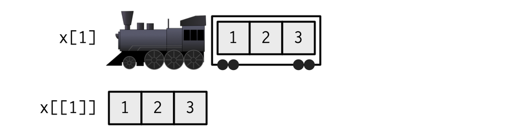

However, because `[[` can return only a single item, you must use it with either a single positive integer or a single string. If you use a vector with `[[`, it will subset recursively, i.e. `x[[c(1, 2)]]` is equivalent to `x[[1]][[2]]`. This is a quirky feature that few know about, so I recommend avoiding it in favor of `purrr::pluck()`, which you’ll learn about next week.

### The $ operator

You should be always using `[[` when extracting a specific column or a row from a data frame/tibble for machine learning purposes. Doing so also reinforces the expectation that you are getting and setting individual values.

An alternative way of doing the same thing is using `$`, which is a shorthand operator: `x$y` is roughly equivalent to `x[["y"]]`. It’s often used to access variables in a data frame, as in `mtcars$cyl` or `diamonds$carat`.

The one important difference between `$` and `[[` is that `$` does (left-to-right) partial matching.

### Simplifying and preserving subsetting

It’s important to understand the distinction between simplifying and preserving subsetting. - Simplifying subsets returns the simplest possible data structure that can represent the output, and is useful interactively because it usually gives you what you need for ML. - Preserving subsetting keeps the structure of the output the same as the input, and is generally better for programming because the result will always be the same type. - Omitting `drop = FALSE` when subsetting matrices and data frames is one of the most common sources of programming errors. It will work for your test cases, but then someone will pass in a single column data frame and it will fail in an unexpected and unclear way.

[output not shown]

### Excercises

**Question 2:** Why does mtcars[1:20] return an error? How does it differ from the similar mtcars[1:20, ]?

**Question 3:** Fix each of the following common data frame subsetting errors:

- `mtcars[mtcars$cyl = 4, ]`
- `mtcars[-1:4, ]`
- `mtcars[mtcars$cyl <= 5]`
- `mtcars[mtcars$cyl == 4 | 6, ]`

**Question 4:** Why does `x <- 1:5; x[NA]` yield five missing values? (Hint: why is it different from`x[NA_real_]`?)

**Question 5:** You have just learned the double bracket operator `[[]]`. It is handy for data frame applications into machine learning, which normally require numerical vectors for input. So let’s experiment a bit.

- How do you think that double bracket operator `[[]]` differs from single bracket operator `[]`?
- What type do you think a single square bracket operator `[]` and double square bracket `[[]]` operator yields on `l1` and `l2`?
- What do you think happens when you add one more bracket to the code? Consider `l2[2][2]` , `l2[2][2][2]` and similar cases.
- Explore types of the following code for subsetting: `l2[2][2]`, `l2[[2]][2]` and `l[2][[2]]`
- Why do you think that `l2[2][2]` returned a list and `l[2][[2]]` returned a vector of double?
- What do you think that `l2[[2]] <- 4` works and `l2[2][[2]] <- 40` does not?

**Question 6:** What does `upper.tri()` return? How does subsetting a matrix with it work? Do we need any additional subsetting rules to describe its behavior?

```r
x <- outer(1:5, 1:5, FUN = "*")
x[upper.tri(x)]
```

```
##  [1]  2  3  6  4  8 12  5 10 15 20
```

**Question 7:** What does `df[is.na(df)] <-` 0 do? How does it work?